# Final Project: **Average Case Constant Factor Time and Distance Optimal Multi-Robot Path Planning in Well-Connected Environments**

Angelica Luna, Stefany Alicea, Emily Chang

Due Date:** May 3, 2018

An Amazon warehouse can cover over one million square feet, roughly 23 acres. Amazon receives, on average during off-peak seasons, 35 orders per second (which is in the vicinity of 1.1 billion orders annually) [^1]. Alibaba, its counterpart in China, fulfills 12.7 billion orders annually. [^2]Physically handling massive inventory is at the crux of growth for these megalithic corporations. In 2015, Amazon acquired a multi-robot system, Kiva, now called Amazon Robotics, for the purposes of streamlining inventory operations; as of 2017, Amazon has 45,000 robots in 20 fulfillment centers. As illustrated above, the real-world applications of multi-robot path planning, then, is plentiful. The article, “Average Case Constant Factor Time and Distance Optimal Multi-Robot Path Planning in Well-Connected Environments”[^3] by Jingjin Yu, a professor at Rutgers University in the computer science department — presents the first low-polynomial running time algorithm called SplitAndGroup (SAG) that solves the multi-robot path planning problem in grids and grid-like, well-connected environments, producing constant factor makespan optimal solutions, also referred to as solutions with sub-linear makespan. Our discussion will be broken into the following sections: (1) Overview and history of the problem and results of the research; (2) Terminology and definitions; (3) Format and schema of the ‘modular’ proof; (4) Analysis of optimality guarantees; (5) Construction of the algorithm; finally, (6) Conclusions and future work.

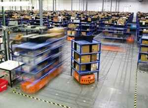

**Figure 1:** Kiva System in action[^4]

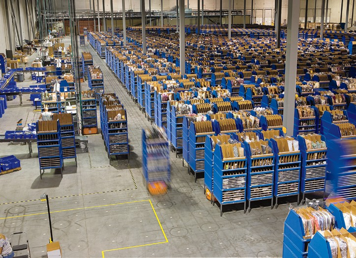

**Figure 2:** Kiva System in action[^5]

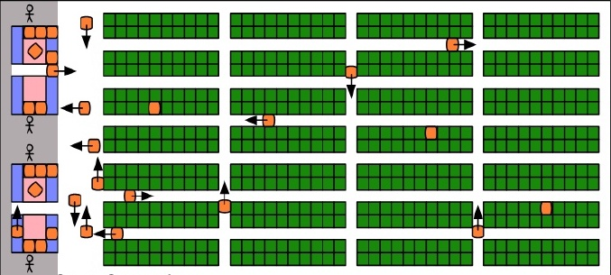

**Figure 3:** Kiva System Layout[^6]

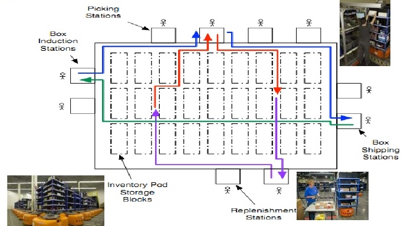

**Figure 4:** Kiva System Order Fetch Configutaion [^7]

**Section I — Overview of the MPP problem:** The issue, at hand, is how to move multiple robots to their respective destinations through efficient paths without collisions, (preferably, in constant factor time, that is, O(1)), with optimal (minimal) distances — this issue is the multi-robot path and motion planning problem, simplified to multi-robot path planning problem or (MPP). The MPP problem, the focus of many studies over several decades, is ‘strongly NP-hard’. However, in discrete settings, solutions on grid-based environments are feasible and solvable in $O(|V|^3)$ time where |V| is the order of the discrete graph, i.e., the number of nodes/vertices. The question is ‘what algorithm(s) could perform the task in sub-linear time?’ Moreover, what conditions would allow for such an algorithm to be feasible. According to Dr. Yu, SplitAndGroup (SaG) is the first, low-polynomial running time, deterministic algorithm which combines the routing methods of both a divide-and-conquer technique as well as a network flow based method. For SaG to perform as an average case O(1)-approximation algorithm computing solutions with sub-linear makespan, the environment must be a grid where all nodes of the underlying graph are occupied (i.e., there is a robot in every position), such that the start and end configurations have the same size, (denoted with the notation: $|X_1| = |X_G|)$. Moreover, the environment is well-connected, a term, along with others, we shall define shortly.

**Section II — Terminology and Definitions:** We now introduce the terms and definitions (italicized and bolded) in the context of the MPP problem. A MPP problem is defined by a 3-tuple, **$(G, X_1, X_G)$** where **$X_1$** and **$X_G$** are two **configurations** (that is, the initial and goal configurations). So, above, we mentioned that one of the constraints of the SaG algorithm is every node is occupied by a robot, thus, the size of the start and goal configurations are the same: $|X_1| = |X_G|$. Overall, we want a **sub-linear makespan** solution; **makespan** is the time span from the start to the end of the task of, let’s say, moving a ‘herd’ of robots from one destination to another. **Sub-linear** refers to a function that is, in asymptotic notation (the big O and little O estimation notation), f(n) = o(n); in other words, whenever $n ≥ n_0$ implies 0 ≤ f(n) < c·n , i.e., f(n) is strictly less than linear. So, we desire a time span solution that is strictly less than linear.

We mentioned above that SaG performs as an **average case O(1)-approximation algorithm**. In contrast to worst case complexity algorithms (as discussed in CSC250 Lectures) which looks at maximal complexity as measured over all inputs, **average case** complexity takes an average over all inputs. The big O notation of **O(1)**, denotes constant time complexity; and **approximation algorithms** are efficient algorithms that approximate the solutions for NP hard optimization problems. As a note, MPP is an double optimization problem for we attempt to optimize not only the time (makespan) for robots to get from one place to another, but also the minimal distance of the path. **TMPP** denotes the Minimum Makespan MPP problem: Given G, $X_1$, and $X_G$, compute the a sequence of moves to takes $X_1$ to $X_G$ while minimizing the makespan. Similarly, **DMPP** denotes the Minimum Total Distance MPP problem: Given G, $X_1$, and $X_G$, compute the a sequence of moves to takes $X_1$ to $X_G$ while minimizing the total distance traveled.

The properties exhibited by the SplitAndGroup (SaG) algorithm is a result of a combination of the **divide-and-conquer** technique and **network flow based** methods. The former, **divide-and-conquer**, is a ‘modular’ approach to problem solving that recursively breaks down a problem into smaller components; solutions to the smaller problems, then, are combined to give a solution to the whole problem. The paradigm is used in constructing and proving that SplitAndGroup (SaG) has a low polynomial run time; the algorithm is broken recursively into smaller problems that are proved as lemmas which, then, are used to prove the theorems. The latter, **network flow based** methods, refers to an optimization theoretic problem of finding the maximum flow from a source to a sink in a network, typically represented as a graph.

However, to prove these properties of SaG, the setting is not arbitrary; in fact, one of the corollaries (Corollary 3) in the paper is that “TMPP does not admit solutions with linear or sub-linear makespan on an arbitrary graph.” We must restrict the classes of graphs to be discrete, grid-like environments that are **well-connected**. To be a well-connected environment, grids are composed of small cycles which allow the **2-switch operation** to be locally performed. Additionally, multiple 2-switches can be completed between two adjacent rows (or columns).

The following list of terms are the ‘modular’ structures or operations that are used in the set-up and in the construction of the algorithm: **Figure-8 graphs**, **2-switch operation**, **3-step plan**, **flip(·) operation**, **herding operation**, **crossover**, **overlaps**, **interacting bundle**. We will introduce them by logically building on the previous term(s). A figure-8 graph is a class of graphs with order $|V| = 7n + 6$ for some positive integer n wherein the graph is formed from 3 disjoint paths of lengths: n, $3n+2$, and $3n+2$ — in which all three paths are connected at two common end nodes. Below are figure-8 graphs with n = 1; observe: the two common end nodes in the upper left figure-8 graph are nodes 1 and 7.

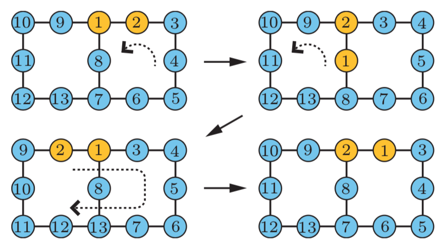

**Figure 5:** Illustration of 3-step process with 2-switch operations on a figure-8 graph

A **2-switch operation** is a sequence of moves; (as in group theory, regarding permutation groups, we can decompose any cycle into a product of 2-cycles or transpositions). A **three-step plan** is decomposition of the exchange of any two robots on the figure-8 graph into a sequence of 2-switches (which we will illustrate using the figure above). To exchange nodes 1 and 2 in the upper left figure-8 graph: first, rotate the right sub-cycle counterclockwise by one node; second, rotate the left sub-cycle counterclockwise by one node; third, rotate the outer cycle clockwise by one node. The algorithm exchanges nodes 1 and 2!

**SplitAndGroup (SaG)** algorithm is so dubbed because it **‘splits’** the grid environment into smaller grids, $G_1$ and $G_2$, and **groups** (as a ‘herd’) the robots, as illustrated below. The objective is to move the blue robots from $G_1$ to $G_2$ or the red robots from $G_2$ to $G_1$. (Note: all the nodes are occupied by a robot, but only the ones that need to move are shown. The remaining robots are expected to return to their original position)

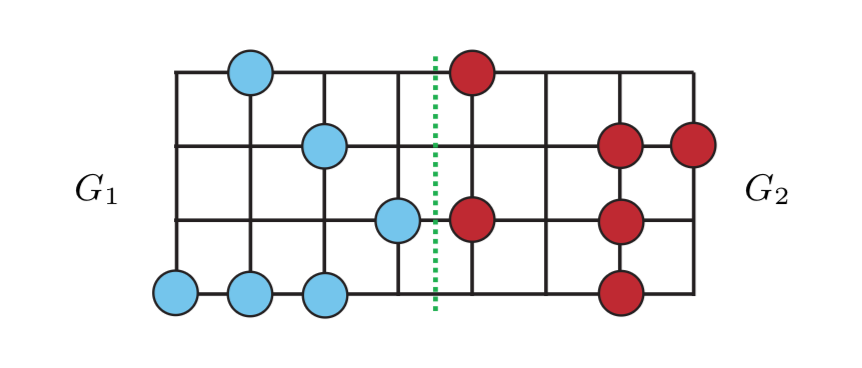

**Figure 6:** Illustration of splitting overall grid into two partitions, $G_1 and G_2$

The flip(·) **operation**, is recursively applied to parallel two-robot exchanges on partitions of the original grid into multiple disjoint blocks. The **herding operation** is the application of the flip(·) **operation** on two disjoint groups of robots where each group is comprised of two-robot exchanges. A crossover occurs if with two trees (that is, acyclic and connected spanning subgraphs of the original grid), $T_1$ and $T_2$, a horizontal path of one tree intersects with a horizontal path of the other tree and forms a ‘cross’ sign with the vertical segment of the other. Below is an illustration of (a) a legitimate crossover; (b) not a crossover; (c) an impossible crossover scenario.

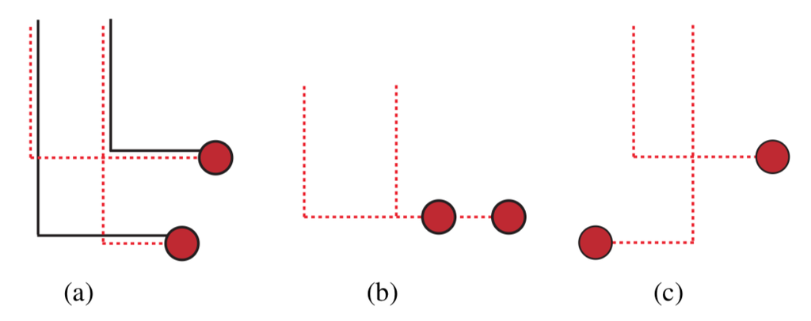

**Figure 7:** Illustration of crossover (i.e., collisions) scenarios

In the **SplitAndGroup (SaG)** algorithm, crossovers are removed, and tree structures can only overlap horizontally. When two trees overlap, we say $T_1$ is a **follower** of $T_2$ if a robot going to $T_2$ must pass through the vertical path of of $T_1$, and $T_2$ is a **leader**. (In the illustration below, $T_1$ is a follower of $T_2$.)

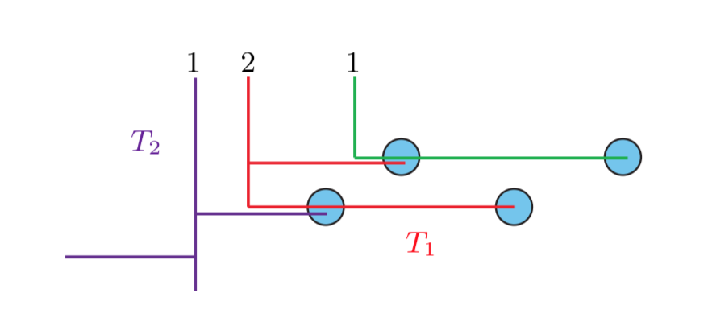

**Figure 8:** Illustration of leader and follower trees

There are various properties of **overlapping** trees: (i) two trees have at most one overlapping horizontal branch; (ii) any three trees cannot pairwise overlap at different rows, and (iii) at least one tree is not a **follower tree** – it is a **leader tree**. Finally, an **interacting bundle** is a collection of a leader tree with its recursively collected followers, and the recursively collected followers of these followers. Illustrated below is an interacting bundle with an initial configuration of the robots on the overlapping horizontal tree branches (top row of trees) followed by the movement of the robots through vertical paths (middle, then followed by bottom row). This is important to create a collision free environment where a robot can only move one step at a time, only if there is a clear path for it; the robots “following” it would then proceed.

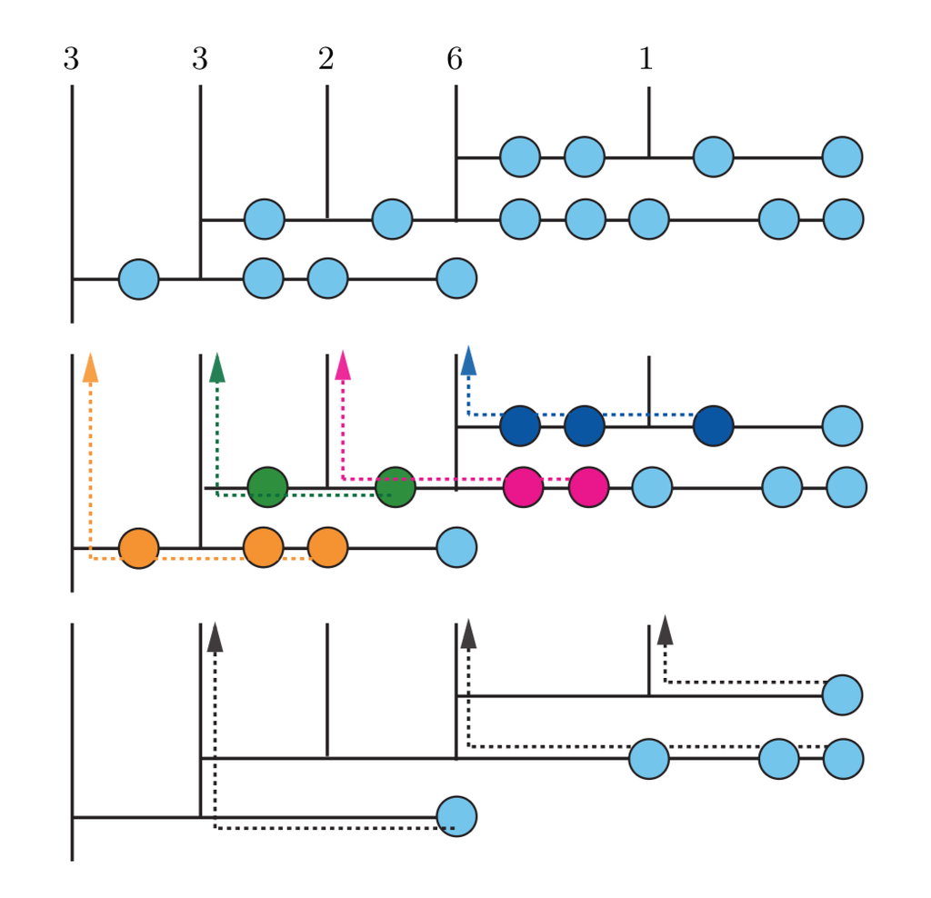

**Figure 9:** Illustration of an interacting bundle: a leader tree with its recursive followers

**Section III —Format of the Proof:** Schematically, on a meta-level, the structure of the overall paper is built on ‘modular’ lemmas that serve as ‘Lego blocks’ from which the theorems are ‘built’. All the proofs for the lemmas and the theorems are algorithmic construction arguments with an account or estimation of the number of steps. The heart of the paper is *Theorem 4:* Let (G, $X_1,X_G$) be an arbitrary TMPP instance in which G is an $m_l$ x $m_s$ grid. The instance admits a solution with O($m_l$) makespan. (As a note, the 3-tuple describes a MPP instance and $m_l$ x $m_s$ are a pair of integers describing the grid size of unit edge lengths.) To prove Theorem 4, the groundwork is laid first with Lemma 1, Proposition 2 and Corollary 3, followed by Lemmas 5-7 and Theorem 8. The conclusion of the paper are Lemma 9, Theorem 10 and Theorem 11 – the three address the TMPP and DMPP optimality problem, that is, the time complexity and space complexity optimality guarantees, respectively. Briefly, we will outline the entire paper.

*Lemma 1*, Proposition 2 and Corollary 3 set-up of the environment for which the SaG algorithm can produce an optimal makespan solution. Starting with Lemma 1: An arbitrary MPP instance (G, $X_I,X_G$) is feasible when G is a figure-8 graph. This lemma demonstrates in a construction argument that on the class of figure-8 graphs, an arbitrary MPP instance is possible. *Lemma 1* proves this by constructing an argument to exchange two robots in a 3-step procedure using a 2-switch operation (illustrated in Figure 5, above). Hence, by Lemma 1’s argument, the figure-8 graphs establishes the groundwork that optimal solutions are not possible on **arbitrary connected paths**. Next, *Proposition 2:* There exists an infinite family of TMPP instances on figure-8 graphs with ɷ(|V|) minimum makespan. This proposition implies that the existence of solutions with linear (or sub-linear) makespan (with respect to the order, i.e., the number of nodes, of the graph) is not necessarily possible if the classes of graphs are not restricted. Finally, *Corollary 3:* TMPP does not admit solutions with linear or sub-linear makespan on an arbitrary graph.

Keeping in mind that MPP is a NP Hard problem, SaG is intended to approximate a solution to the MPP problem under strict environmental conditions. Although there are countless variables to keep track of such as storing all the calculations for possible robot paths, the author of this paper is explicit in stating that the reason SaG can run on linear or sub-linear time is because for any finite number of robots on a grid-like, well connected environment, there would always be a finite number of paths to calculate. Once we calculate those paths, we can find and exclude crossovers (i.e., collisions) so to calculate the finite number of steps of each robot. Without these environmental restrictions, the solution would be exponential in the number of steps, again, reminding us that MPP is a NP-Hard problem.

On rectangular grids, we investigate the heart of the paper, the **SplitAndGroup (SaG)** algorithm in the proof of Theorem 4 — *Theorem 4*:

Let (G, $X_1,X_G$) be an arbitrary TMPP instance in which G is an $m_l$ x $m_s$ grid. The instance admits a solution with O($m_l$) makespan.

To achieve an O($m_l$) makespan, the algorithm must allow concurrent robot movements which is especially challenging due to the initial assumption that every node is occupied by a robot. Fortunately, we prescribed that the environment is a grid which allows us to perform concurrent ‘flipping’ operations as demonstrated, earlier in Lemma 1, in the 3-step process on figure-8 graphs. So, *Lemma 5*:

Let G = (V,E) be an $m_l$ x $m_s$ grid. Let E’⊂ E be a set of vertex disjoint edges. Then the flip(E’) operation can be completed in a constant number of steps.

The significance of Lemma 5 is to show that flip(·) operation can perform the concurrent exchange of adjacent robots in O(1) steps. To cover all possible paths for a graph G, we use Lemma 1 to partition an overall graph into figure-8 graphs where we can perform the 3-step process using 2-switch operations. The flip(E’) operation is broken down and used in parallel robot exchanges on these subgraphs (i.e., the partitions). Lemma 5 proves that by this process, O($m_l$) number of FLIP(·) operations can be performed with a time complexity of O(1) because we are essentially decomposing the graph into these smaller subgraphs and then adding up the finite number of FLIP(·) operations performed of each subgraph.

Next, we need to show that grouping robots on trees is done efficiently and, furthermore, that we do not distinguish robots within the group – Lemma 6 argues this claim. *Lemma 6*:

Let P be a path of length L embedded in grid. An arbitrary group of up to ⌊L/2⌋ robots on P can be relocated to one end on P in O(L) steps. Furthermore, the relocation may be performed using flip(·) on P.

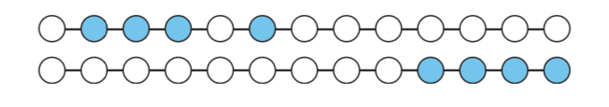

Let P be a path of length **$l$** embedded in grid. Let two groups, equal in number, reside on two non-intersecting segments of P. Then positions of the two groups of robots may be exchange in O(l) steps without net movements of other robots. The relocation may be performed using on flip(·) P.

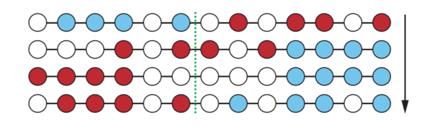

Lemma 7 is proven by building on Lemma 6’s efficient herding of a group, then observing that exchanging two disjoint groups is a parallel ‘reversed’ herding operation. Since each of the herding operations takes O(L) steps (whether forward or reverse), the overall process is O(L) steps. Finally Theorem 8 demonstrates how we generalize all the proceeding operations (Lemmas 5-7) on a tree. *Theorem 8*:

Let T be a tree of diameter d embedded in a grid. Let P be a length l path branch of T. Then, a group of robots on P can be exchanged with robots on T outside P in O(d) steps without net movement of other robots. The relocation may be performed using on flip(·) T.

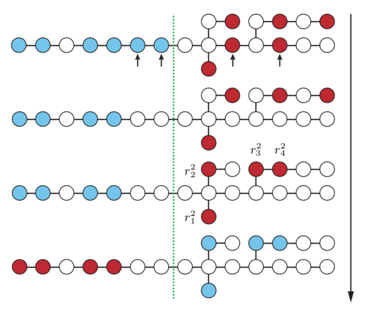

Like Lemma 7, the proof of Lemma 8 is based on a forward and reverse exchange operations on a herd of robots; only now we must consider first doing the exchange of robots from the branches onto the main path for one herd of robots and then reversing the operations of moving robots from the main path onto a branch. Again, the number of steps for the forward or reverse procedure is finite, O(d) where d is length/distance of each branch; hence the overall number of steps has O(1) time factor.

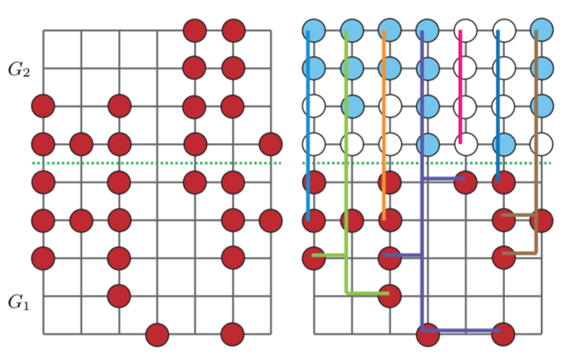

With the constructions of these operations proven in Lemmas 5-7 and Theorem 8, Theorem 4 takes an account of the number of steps of one iteration of the SaG algorithm which essentially uses Theorem 8’s results. The accounting for algorithm is as follows: (1) the splitting of the current grid; (2) case analysis of the different initial configurations of a herd of robots on a tree of located on the partition/subgraph, $G_1$ to the next configuration of $G_2$; (3) removing potential collisions called crossovers in the analysis of paths from initial to next configurations, (removing crossovers involves an analysis of how different interacting bundles behave). The first iteration on a $m_l$ x $m_s$ grid can be completed in O($m_l$) steps. With each successive iteration of the SaG algorithm which recursively breaks the grid in half, we end up with O(log $m_l$) iterations; hence, O($m_l$) steps are sufficient for the entire process so the MPP instance admits a solution in O($m_l$) makespan! (Hooray!)

Without Lemma 9, we would not have a sufficient condition for making sure that SaG algorithm delivers an average case O(1) approximation for makespan; that is, the algorithm may instead be addressing a maximal time complexity situation. (In the latter case, we would not be assured of Theorem 4’s validity!) In essence, Lemma 9 is stating that the number of MPP instances on a fixed, discrete graph with a constant factor makespan is less than or equal to (no more than) an exponentially small number; hence, the average makespan is constant, which is *Theorem 10*:

*On average and in polynomial time, SplitAndGroup (SaG) computes O(1)-approximate makespan optimal solutions for MPP.*

*For an average MPP instance, , SplitAndGroup (SaG) computes O(1)-approximate total distance optimal solutions for MPP.*

Thus, both optimization problems are addressed; and optimality is guaranteed.

**Section V — Construction of the Algorithm:** We will run through one iteration of the SaG algorithm as outlined in the proof of Theorem 4, outlined in pseudo-code below. Over all iterations, the total running time, cumulatively accounting for each stage, is $O(|V|^3).$

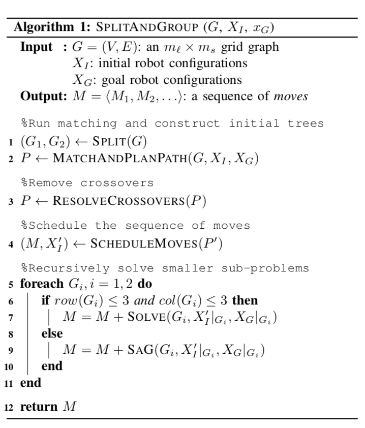

**Figure 14:** Pseudo-code of SplitAndGroup (SaG)

*Theorem 8* builds on this idea by introducing tree paths. The crossover removal operation (which removes possibilities of collisions) is then implemented and will change the paths of robots if needed. One of our restrictions is that only one robot can move at a time, so a schedule of when robots will move is needed. Previously, we discussed the properties of overlapping trees, a leader tree, and a follower tree. This occurs after the moves of robots are scheduled, as there will be overlapping horizontal paths, given that there are no crossovers. Since we only have a finite number of steps, this can be done in O(L) time of a path of length L. At this point, we have calculated the paths for every robot and by doing so we have created a schedule for when they will move; this is essentially steps 1-4 in SaG’s pseudocode (shown above). The rest of the algorithm is explicitly recursive to iterate over the remaining partitioned subgraphs of G. After 2k iterations we will have a makespan of
$$O(m_L) = 2O(mL)+2O(mL/2) + 2O(mL/4)+...+ 2O(1).$$
Because this is still a finite number of steps, since it is dependent of the length L of the grid, its sum will always be finite. To enable concurrent robot movements to achieve a makespan of O($m_L$). First, we must make the worst case assumption that the number of robots will be equal to the number of vertices. Many of the examples we have illustrated above explicitly ignored a number of robots on the grid. This simply means that they were not given an initial and final configuration, $X_I$ and $X_G$. Their movements throughout the graph were not calculated, other than to accommodate the path of those robots moving to their goal configuration. However, the worst case assumption would mean that every robots has an initial and final configuration, $X_I$ and $X_G$. SaG would have to iterate over all possible paths and then exclude crossovers.

*Lemma 9* proves that for all possible paths of one robot to $X_G$, only ¼ have the optimal ¼($m_L$+$m_S$) ≥ distance to $X_G$ from $X_I$. The next possible paths of a robot will be ¼ of the previous one. So the more robot’s we have the smaller the number of optimal paths. Thus, our worst case assumption is when the number of robots is equal to the number of vertices. Our assumptions for the grid graph will be that we can enable concurrent flipping or bubbling of robots; meaning we can have two robots switch positions on grid. This is beneficial, as it can have multiple iterations of SaG running on different subgraphs. Still, the paper offers examples with fixed restrictions are to prove a solution with constant linear and sublinear makespan.

**Section VI — Conclusion and Future Work:** As mentioned in the beginning, the environment is prescribed. So, a valid question is ‘what if every node is not occupied by a robot?’ Future work may involve finding an optimal solution for an environment with a lower amount of robots. Although the conditions for SaG are not realistic, SaG provides a platform to finding a general solution to a PTAS (polynomial time approximation scheme), a type of approximate algorithm that can give the user control on accuracy, for the MPP problem. Although we gave an example in the introduction of why the MPP may be of importance, especially in relation to path planning for multi-robots in giant warehouses, other applications such as traffic and intersections is a prime real-world application of the MPP problem.

[^1]: Feinberg, Ashley. “Life in an Amazon Warehouse: Fear and Efficiency at 35 Orders per Second.” Gizmodo. Feb 8, 2013. https://gizmodo.com/5982811/life-in-an-amazon-warehouse-fear-and-efficiency-at-35-orders-per-second [retrieved April 22, 2018]
[^2]: Go-Globe editors. “Alibaba in Numbers: Statistics and Trends.” Go Globe. Feb 19, 2015. https://www.go-globe.com/blog/alibaba-statistics-trends/ [retrieved April 22, 2018]
[^3]: Yu, Jingjin. “Average Case Constant Factor Time and Distance Optimal Multi-Robot Path Planning in Well-Connected Environments.” 24 Feb. 2018.
[^4]: Poudel, D. “Coordinating Hundreds of Operative, Autonomous Vehicles in a Warehouse,” Automation and Control Seminar. July 30, 2012. https://www.slideshare.net/devbp/kiva-system [retrieved April 28, 2018]
[^5]: Poudel, D. “Coordinating Hundreds of Operative, Autonomous Vehicles in a Warehouse,” Automation and Control Seminar. July 30, 2012. https://www.slideshare.net/devbp/kiva-system [retrieved April 28, 2018]
[^6]: Poudel, D. “Coordinating Hundreds of Operative, Autonomous Vehicles in a Warehouse,” Automation and Control Seminar. July 30, 2012. https://www.slideshare.net/devbp/kiva-system [retrieved April 28, 2018]
[^7]: Poudel, D. “Coordinating Hundreds of Operative, Autonomous Vehicles in a Warehouse,” Automation and Control Seminar. July 30, 2012. https://www.slideshare.net/devbp/kiva-system [retrieved April 28, 2018]